# Financial Contributions Made to Presidential Candidates by Aaron Gruberg

# Data Description

I downloaded a csv file of contributions made to presidential candidates from Californians for the 2016 election. I looked at how the money was distributed among candidates and which occupations and cities made the largest contributions. Because most of the variables are categorical, I had to create new variables from existing ones. This dataset consists of 18 variables with 1304346 observations.

```
##    cmte_id               cand_id                            cand_nm
##  Length:1304346     P00003392:688524   Clinton, Hillary Rodham  :688524
##  Class :character   P60007168:407164   Sanders, Bernard         :407164
##  Mode  :character   P80001571: 86258   Trump, Donald J.         : 86258
##                     P60006111: 57822   Cruz, Rafael Edward 'Ted': 57822
##                     P60005915: 27370   Carson, Benjamin S.      : 27370
##                     P60006723: 14095   Rubio, Marco             : 14095
##                     (Other)  : 23113   (Other)                  : 23113
##             contbr_nm              contbr_city     contbr_st
##  PETIT, MICHAEL  :    473   LOS ANGELES  :102710   CA:1304346
##  MITCHELL, MARCIA:    409   SAN FRANCISCO: 90937
##  SMITH, CHERYL   :    375   SAN DIEGO    : 46129
##  SAMATUA, DENISE :    373   OAKLAND      : 33235
##  CARROLL, TERI   :    352   SAN JOSE     : 30674
##  ADAM, MONIQUE   :    321   SACRAMENTO   : 23799
##  (Other)         :1302043   (Other)      :976862
##      contbr_zip           contbr_employer               contbr_occupation
##  92660    :    660   N/A          :185382   RETIRED              :260546
##  92037    :    565   RETIRED      :121569   NOT EMPLOYED         :115598
##  90049    :    495   SELF-EMPLOYED:120187   ATTORNEY             : 36640
##  92677    :    483   NONE         : 84297   INFORMATION REQUESTED: 30948
##  92067    :    474   NOT EMPLOYED : 50821   TEACHER              : 29104
##  911075001:    473   (Other)      :741411   (Other)              :831369
##  (Other)  :1301196   NA's         :   679   NA's                 :   141
##  contb_receipt_amt   contb_receipt_dt
##  Min.   :-10500.0   29-FEB-16:  11735
##  1st Qu.:    15.0   31-MAR-16:  11506
##  Median :    27.0   31-MAY-16:  10435
##  Mean   :   116.2   31-OCT-16:  10220
##  3rd Qu.:    88.0   06-NOV-16:  10199
##  Max.   : 10800.0   01-NOV-16:  10082
##                     (Other)  :1240169
##                                   receipt_desc     memo_cd
##                                         :1287456    :1104791
##  Refund                                 :  10413   X: 199555
##  REDESIGNATION FROM PRIMARY             :   1324
##  REDESIGNATION TO GENERAL               :   1324
##  REATTRIBUTION / REDESIGNATION REQUESTED:    569
##  REDESIGNATION TO CRUZ FOR SENATE       :    544
##  (Other)                                :   2716
##                                memo_text       form_tp
##                                     :776701   SA17A:1101230
##  * EARMARKED CONTRIBUTION: SEE BELOW:394270   SA18 : 192703
##  * HILLARY VICTORY FUND             :122912   SB28A:  10413
##  REDESIGNATION FROM PRIMARY         :  1324
##  REDESIGNATION TO GENERAL           :  1324
##  *BEST EFFORTS UPDATE               :  1256
##  (Other)                            :  6559
##     file_num                       tran_id        election_tp
##  Min.   :1003942   A5602AD777C8C4632B5A:      4        :  1695
##  1st Qu.:1077916   ADB49CB248C174E298F0:      4   G2016:483991
##  Median :1099613   A26C35A6066754130B99:      3   O2016:   632
##  Mean   :1102796   A340DF85B7F884133A20:      3   P2016:818021
##  3rd Qu.:1133832   A4E50E2DD07E4475996F:      3   P2020:     7
##  Max.   :1146285   A7C22FA389E0348F98F0:      3
##                    (Other)             :1304326
```

# Univariate Plots Section

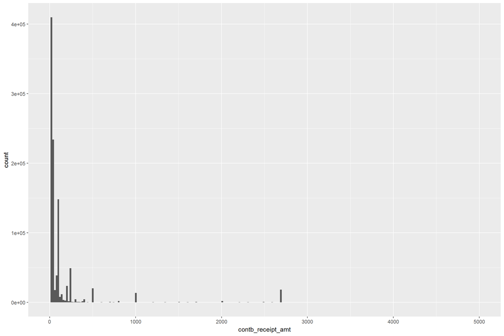

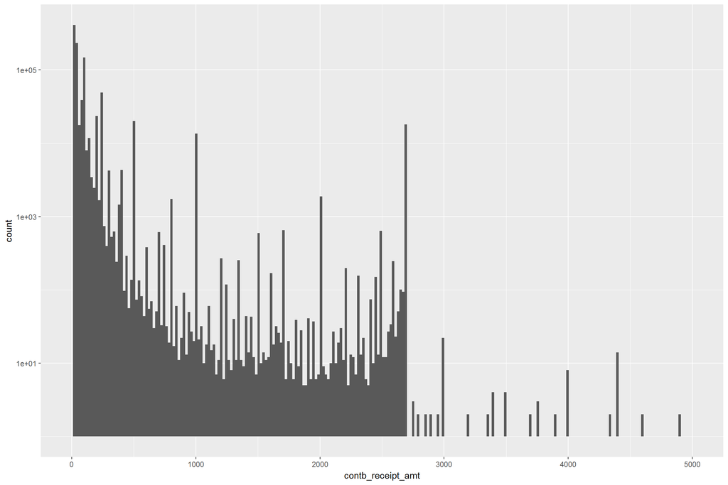

The count of contribution amounts was very spread out. There appear to be large gaps in the first histogram between contributions of $500 and $3000.  
Once I applied a log10() scale to the y axis these smaller counts were visible.

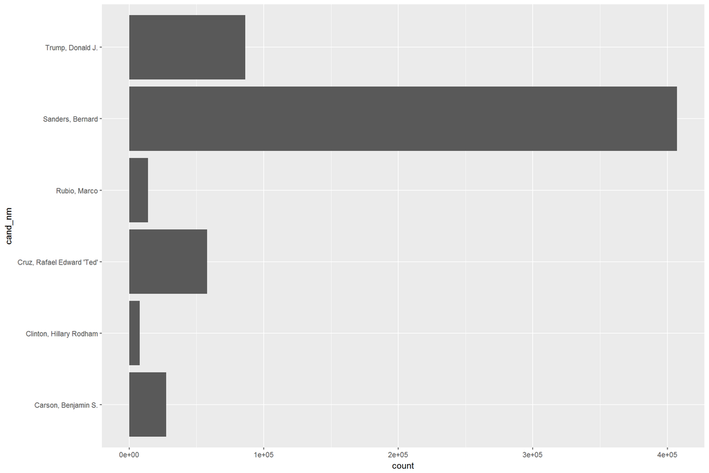

This is a histogram of the number of contributions top candidates received from unemployed people. Bernie Sanders received the most contributions from this group of people.

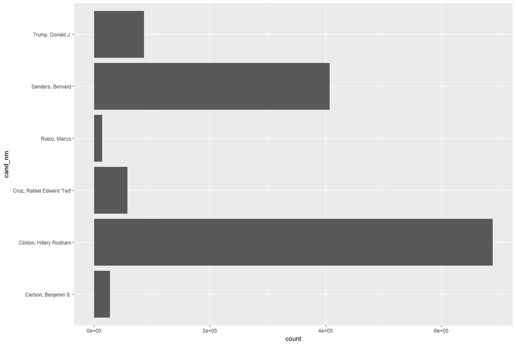

This is the number of contributions top candidates received from employed people. Hillary Clinton received the most contributions from employed people.

```r
### Amount vs Date
### Change the date format by adding new date column
CA$contb_receipt_dt_date <- as.Date(CA$contb_receipt_dt, "%d-%b-%y")

### Add new columns for Year, Day, Month
CA$year = as.numeric(format(CA$contb_receipt_dt_date, format = "%Y"))
CA$month = as.numeric(format(CA$contb_receipt_dt_date, format = "%m"))
CA$day = as.numeric(format(CA$contb_receipt_dt_date, format = "%d"))
```

I used the ‘as.Date’ function to create a variable called contb_receipt_dt_date which converts the date format from ‘26-APR-16’ to ‘2016-04-26’. Then I added 3 variables for the ‘day’, ‘month’, ‘year’.

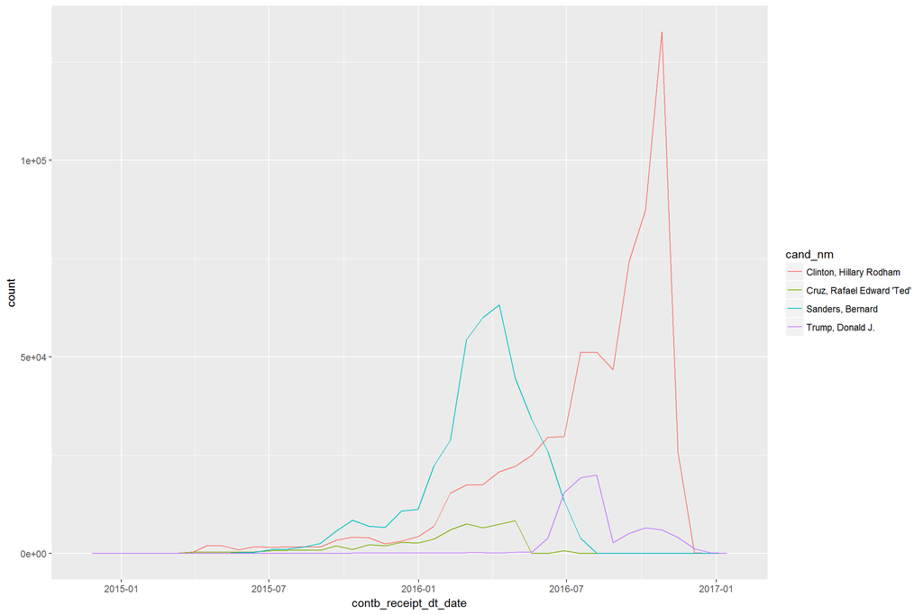

```
##                                RETIRED
##                                 260546
##                           NOT EMPLOYED
##                                 115598
##                               ATTORNEY
##                                  36640
##                  INFORMATION REQUESTED
##                                  30948
##                                TEACHER
##                                  29104
##                               ENGINEER
##                                  17749
##                              HOMEMAKER
##                                  17268
##                              PHYSICIAN
##                                  16111
##                      SOFTWARE ENGINEER
##                                  15156
##                              PROFESSOR
##                                  14949
##                             CONSULTANT
##                                  13961
##                                 WRITER
##                                  12654
##
##                                  10548
##                                MANAGER
##                                  10421
##                                  SALES
##                                  10287
##                                 LAWYER
##                                   8945
##                       REGISTERED NURSE
##                                   7439
##                                 ARTIST
##                                   7303
##                                    CEO
##                                   7174
##                                STUDENT
##                                   7097
```

[output cut: 145 more lines]

```
##                                   1244
##                                     IT
##                                   1229
##                                     MD
##                                   1225
##                          SALES MANAGER
##                                   1194
##                                 BANKER
##                                   1163
##                           TRUCK DRIVER
##                                   1142
##                                (Other)
##                                 452427
##                                   NA's
##                                    141
```

# Univariate Analysis

### What is the structure of your dataset?

There are 1304346 transactions in the dataset with 18 features(cmte_id, cand_id, cand_nm, contbr_name, contbr_city, contbr_state, contbr_zip, contbr_employer, contbr_occupation, contb_receipt_amt, contb_receipt_dt, receipt_desc, memo_cd, memo_text, form_tp, file_num, tran_id, election_tp).  
Most variables in the original dataset were categorical.

### What is/are the main feature(s) of interest in your dataset?

The main features in the dataset are contb_receipt_amt and cand_nm. I’m interested in the amount of money going to a particular candidate and how it varies across categorical variables such as industry category, and county.

### What other features in the dataset do you think will help support your investigation into your feature(s) of interest?

I also examine contb_receipt_dt to see how often a particular contribution is made as we get closer to the election date.

### Did you create any new variables from existing variables in the dataset?

I created a variable called contb_receipt_dt_date which converts the date format from ‘26-APR-16’ to ‘2016-04-26’. Then I added 3 variables for the ‘day’, ‘month’, ‘year’.

I created a variable ‘total_contbr’ to sum all the contributions a particular candidate receives on a particuluar date, and ‘max_total_contbr’ to find the cumulative sum a candidate received from all contributors on a particular date.

I created the variable ‘contbr_county’ so I could group the values in the ‘contbr_city’ column and include this geographical data in my plots.  
‘contbr_county’ includes 7 counties(LA, SD, ORANGE, SAC, RIVERSIDE, SAN BERN, BAY AREA).

### Of the features you investigated, were there any unusual distributions? Did you perform any operations on the data to tidy, adjust, or change the form of the data? If so, why did you do this?

There was a sharp cutoff in the histogram of contribution amounts for values of $2700. After this limit, far fewer counts were recorded. I was expecting to see a distribition that resembled an exponential decay but there were also large spikes for contributions of 1000, 2000, and 2700.

I used ‘as.numeric’ to convert the date values to numeric date values. This allowed me to take the log of numeric date values for scaling purposes.

# Bivariate Plots Section

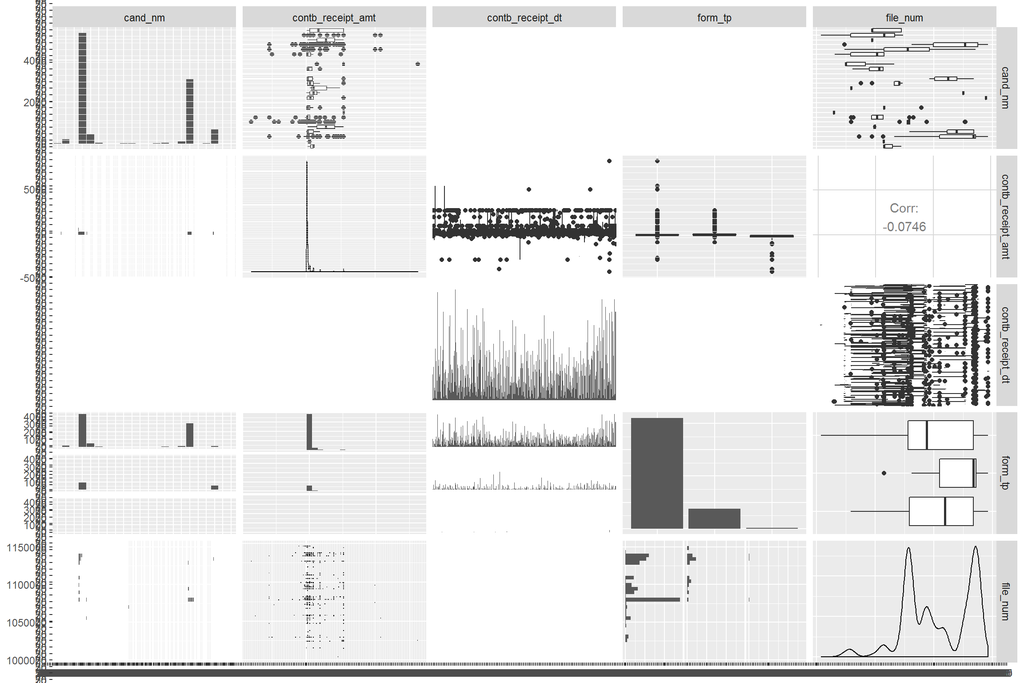

This plot matrix plots each variable against every other variable. It wasn’t very helpful for this dataset because most of the data were very large categorical variables. This produced boxplots with hundredes of categorical values on the x axis.

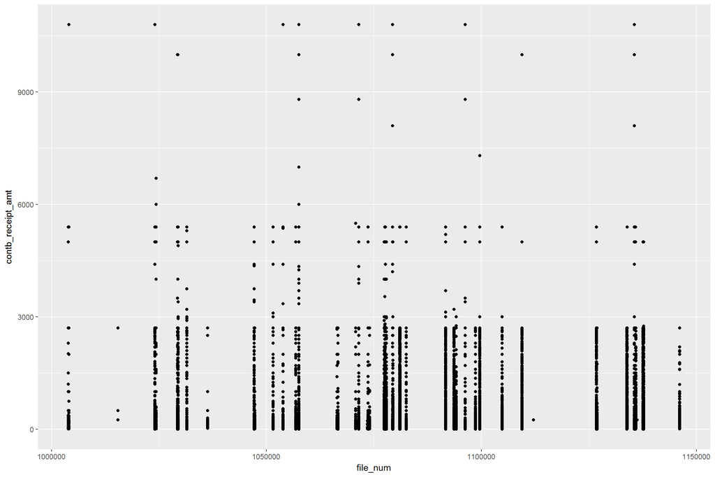

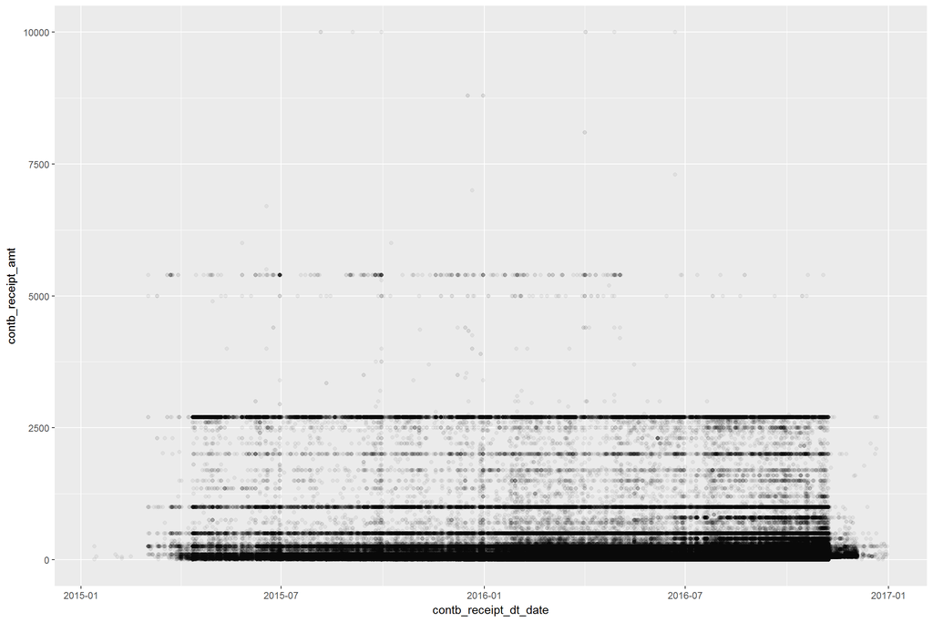

Scatter plot of amount vs. date for selected candidates.

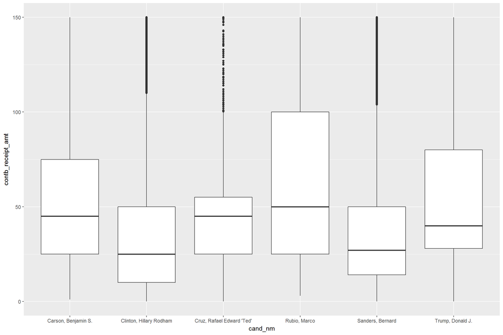

```
## CA$cand_nm: Bush, Jeb
##    Min. 1st Qu.  Median    Mean 3rd Qu.    Max.
##   -5400      50     500    1054    2700   10000
## --------------------------------------------------------
## CA$cand_nm: Carson, Benjamin S.
##     Min.  1st Qu.   Median     Mean  3rd Qu.     Max.
## -10000.0     25.0     50.0    106.4    100.0  10000.0
## --------------------------------------------------------
## CA$cand_nm: Christie, Christopher J.
##    Min. 1st Qu.  Median    Mean 3rd Qu.    Max.
##   -2700     100    1000    1370    2700    5400
## --------------------------------------------------------
## CA$cand_nm: Clinton, Hillary Rodham
##    Min. 1st Qu.  Median    Mean 3rd Qu.    Max.
## -5400.0    15.0    25.0   136.1   100.0 10000.0
## --------------------------------------------------------
## CA$cand_nm: Cruz, Rafael Edward 'Ted'
##     Min.  1st Qu.   Median     Mean  3rd Qu.     Max.
## -8300.00    25.00    50.00    99.11   100.00 10800.00
## --------------------------------------------------------
## CA$cand_nm: Fiorina, Carly
##    Min. 1st Qu.  Median    Mean 3rd Qu.    Max.
## -3300.0    25.0   100.0   308.3   250.0  5400.0
## --------------------------------------------------------
## CA$cand_nm: Gilmore, James S III
##    Min. 1st Qu.  Median    Mean 3rd Qu.    Max.
##    2700    2700    2700    2700    2700    2700
## --------------------------------------------------------
## CA$cand_nm: Graham, Lindsey O.
##    Min. 1st Qu.  Median    Mean 3rd Qu.    Max.
##   -2700     100    1000    1195    2700    8100
## --------------------------------------------------------
## CA$cand_nm: Huckabee, Mike
##    Min. 1st Qu.  Median    Mean 3rd Qu.    Max.
## -2700.0    25.0    50.0   434.8   500.0  5400.0
## --------------------------------------------------------
## CA$cand_nm: Jindal, Bobby
##    Min. 1st Qu.  Median    Mean 3rd Qu.    Max.
##    11.1   250.0   250.0   749.4  1000.0  2700.0
## --------------------------------------------------------
```

[output cut: 44 more lines]

```
## CA$cand_nm: Stein, Jill
##    Min. 1st Qu.  Median    Mean 3rd Qu.    Max.
##  -300.0    35.0   100.0   264.5   250.0  2700.0
## --------------------------------------------------------
## CA$cand_nm: Trump, Donald J.
##    Min. 1st Qu.  Median    Mean 3rd Qu.    Max.
## -8900.0    28.0    80.0   162.4   195.4  5400.0
## --------------------------------------------------------
## CA$cand_nm: Walker, Scott
##    Min. 1st Qu.  Median    Mean 3rd Qu.    Max.
## -5400.0   100.0   250.0   678.7  1000.0 10800.0
## --------------------------------------------------------
## CA$cand_nm: Webb, James Henry Jr.
##    Min. 1st Qu.  Median    Mean 3rd Qu.    Max.
##     5.0   100.0   275.0   722.3   875.0  5400.0
```

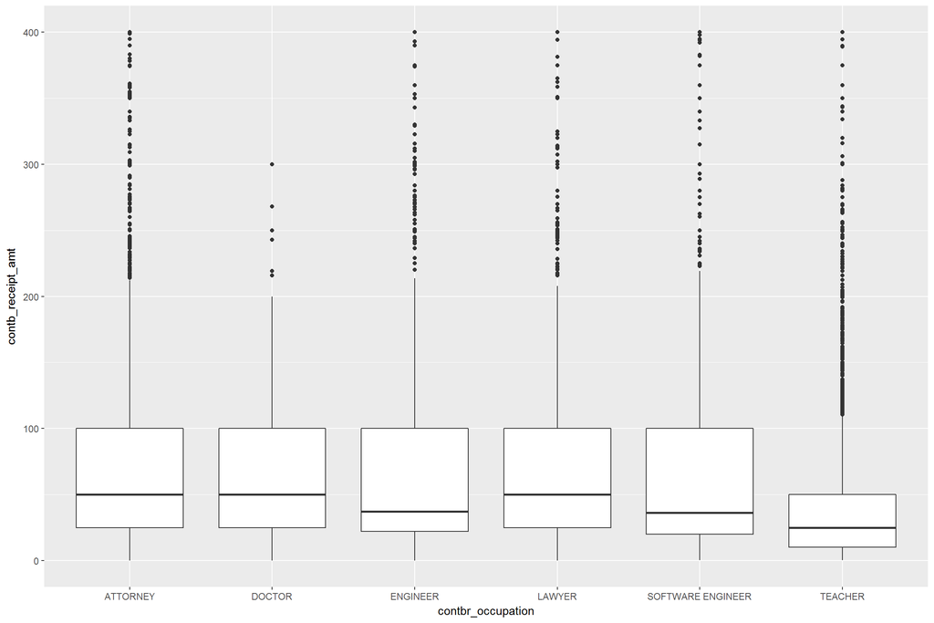

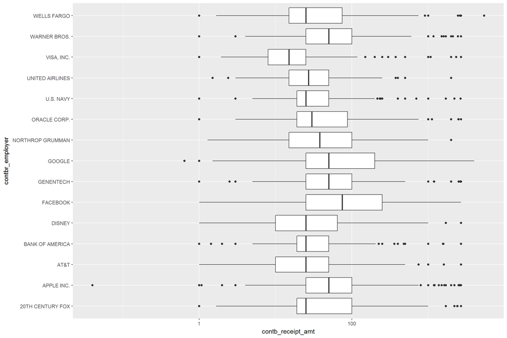

Boxplots of contributions amount vs. candidate name, contributor occupation, and contributor employer.

```r
### Boxplot of amount vs. industry

### Create vectors for each 'job field' for selected jobs
WHITE_COLLAR <- c("ENGINEER", "SOFTWARE ENGINEER", "SOFTWARE DEVELOPER",
                  "WEB DEVELOPER", "IT", "ARCHITECT", "SCIENTIST",
                  "RESEARCHER", "PHYSICIAN", "REGISTERED NURSE", "NURSE",
                  "RN", "PHARMACIST", "NURSE PRACTITIONER", "DENTIST",
                  "DOCTOR", "MD", "PSYCHOLOGIST", "LAWYER", "ATTORNEY",
                  "PARALEGAL", "JUDGE ADVOCATE", "JUDGE", "SALES",
                  "SALES MANAGER", "ANALYST", "MARKETING", "CONSULTANT",
                  "REALTOR", "DESIGNER", "PROJECT MANAGER", "ADMINISTRATOR",
                  "REAL ESTATE", "HUMAN RESOURCES", "PROPERTY MANAGER",
                  "REAL ESTATE BROKER", "ACCOUNTANT", "FINANCE", "CPA",
                  "INVESTOR", "BANKER", "CEO", "CFO", "PRESIDENT",
                  "VICE PRESIDENT", "EXECUTIVE", "TEACHER", "PROFESSOR",
                  "COLLEGE PROFESSOR", "EDUCATOR", "BEHAVIORAL THERAPIST",
                  "PHYSICAL THERAPIST", "LECTURER", "MATHEMATICS INSTRUCTOR",
                  "BUSINESS DEVELOPMENT", "BIOLOGIST", "SOCIAL WORKER",
                  "GAME DEVELOPER", "SURGEON", "DATABASE ADMINISTRATOR",
                  "CHIEF FINANCIAL OFFICER", "DATA SCIENTIST",
                  "DEV-OPS ENGINEER", "AEROSPACE ENGINEER")

BLUE_COLLAR <- c("BUSINESS OWNER", "SMALL BUSINESS OWNER", "OWNER",
                 "ENTREPRENEUR", "SELF EMPLOYED", "FARMER", "TRUCK DRIVER",
                 "DRIVER", "CONTRACTOR", "BOOKKEEPER", "CLERICAL",
                 "SHOP OWNER", "HOMEMAKER", "LABORER", "DELIVERY DRIVER",
                 "SECRETARY", "TSA OFFICER", "SALON/SPA", "FORKLIFT DRIVER",
                 "DATA ENTRY", "COOK", "SECURITY GUARD", "ELECTRICIAN",
                 "ASSISTANT MANAGER", "RETAIL SALES", "DEALER",
                 "CUSTOMER SERVICE", "FLIGHT ATTENDANT", "FIRE FIGHTER",
                 "CARPENTER", "RANCHER", "CASHIER", "SERVER", "WAITER",
                 "WAITRESS")

STUDENT <- c("STUDENT", "GRADUATE STUDENT")

UNEMPLOYED <- c("DISABLED", "NOT EMPLOYED", "UNEMPLOYED",
                "UNEMPLOYED BECAUSE OF OBAMACARE")

MILITARY <- c("U.S. NAVY", "UNITED STATES NAVY", "NAVY", "DEPT. OF NAVY",
              "DEPARTMENT OF NAVY", "DEPARTMENT OF THE NAVY",
              "U.S. DEPARTMENT OF THE NAVY", "NAVY FEDERAL CREDIT UNION",
              "USNAVY", "U.S. ARMY", "ARMY", "US ARMY",
              "U.S. DEPARTMENT OF THE ARMY", "U.S. ARMY CORPS. OF ENGINEERS",
              "DEPT OF ARMY", "U S ARMY", "U.S. COAST GUARD", "US COAST GUARD",
              "UNITED STATES COAST GUARD", "U.S. DEPARTMENT OF THE COAST GUARD",
              "DOD", "D.O.D.")

RETIRED <- c("RETIRED")

### Create 'job field' column.  If contbr_occupation is in a job field vector
### from above, add the name of the vector to 'job field' column
CA$contbr_industry <- ifelse(CA$contbr_occupation %in% WHITE_COLLAR,
                             "WHITE COLLAR",
                      ifelse(CA$contbr_occupation %in% BLUE_COLLAR,
                             "BLUE COLLAR",
                      ifelse(CA$contbr_occupation %in% STUDENT,
                             "STUDENT",
                      ifelse(CA$contbr_occupation %in% UNEMPLOYED,
                             "UNEMPLOYED",
                      ifelse(CA$contbr_employer %in% MILITARY,
                             "MILITARY",
                      ifelse(CA$contbr_occupation %in% RETIRED,
                             "RETIRED", "NULL"))))))
```

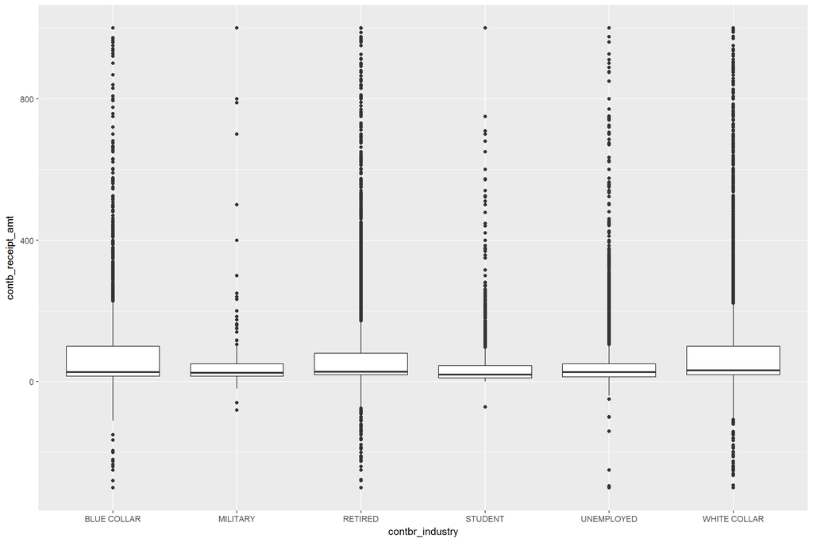

```
## CA$contbr_industry: BLUE COLLAR
##    Min. 1st Qu.  Median    Mean 3rd Qu.    Max.
## -5400.0    15.0    33.0   177.4   100.0 10800.0
## --------------------------------------------------------
## CA$contbr_industry: MILITARY
##    Min. 1st Qu.  Median    Mean 3rd Qu.    Max.
##  -80.00   15.00   25.00   55.55   50.00 2650.00
## --------------------------------------------------------
## CA$contbr_industry: NULL
##    Min. 1st Qu.  Median    Mean 3rd Qu.    Max.
##  -10500      15      27     113      80   10800
## --------------------------------------------------------
## CA$contbr_industry: RETIRED
##     Min.  1st Qu.   Median     Mean  3rd Qu.     Max.
## -5400.00    19.00    30.00    96.57    85.00 10800.00
## --------------------------------------------------------
## CA$contbr_industry: STUDENT
##    Min. 1st Qu.  Median    Mean 3rd Qu.    Max.
## -1000.0    10.0    24.3   114.1    50.0  5500.0
## --------------------------------------------------------
## CA$contbr_industry: UNEMPLOYED
##     Min.  1st Qu.   Median     Mean  3rd Qu.     Max.
## -2300.00    13.50    27.00    55.58    50.00  5000.00
## --------------------------------------------------------
## CA$contbr_industry: WHITE COLLAR
##    Min. 1st Qu.  Median    Mean 3rd Qu.    Max.
## -5400.0    19.0    36.0   154.6   100.0 10800.0
```

I made a boxplot of amount vs. industry category and excluded data from jobs that were not in my industry category lists. Every category had a lot of refund transactions with the exception of military employees and students.

```r
### Make a list of all cities in those counties

LA <- c("AGOURA HILLS", "ALHAMBRA", "ARCADIA", "ARTESIA", "AVALON", "AZUSA",
        "BALDWIN PARK", "BELL", "BELL GARDENS", "BELLFLOWER", "BEVERLY HILLS",
        "BRADBURY", "BURBANK", "CALABASAS", "CARSON", "CERRITOS", "CLAREMONT",
        "COMMERCE", "COMPTON", "COVINA", "CUDAHY", "CULVER CITY", "DIAMOND BAR",
        "DOWNEY", "DUARTE", "EL MONTE", "EL SEGUNDO", "GARDENA", "GLENDALE",
        "GLENDORA", "HAWAIIAN GARDENS", "HAWTHORNE", "HERMOSA BEACH",
        "HIDDEN HILLS", "HUNTINGTON PARK", "INDUSTRY", "INGLEWOOD", "IRWINDALE",
        "LA CANADA FLINTRIDGE", "LA HABRA HEIGHTS", "LA MIRADA", "LA PUENTE",
        "LA VERNE", "LAKEWOOD", "LANCASTER", "LAWNDALE", "LOMITA", "LONG BEACH",
        "LOS ANGELES", "LYNWOOD", "MALIBU", "MANHATTAN BEACH", "MAYWOOD",
        "MONROVIA", "MONTEBELLO", "MONTEREY PARK", "NORWALK", "PALMDALE",
        "PALOS VERDES ESTATES", "PARAMOUNT", "PASADENA", "PICO RIVERA",
        "POMONA", "RANCHO PALOS VERDES", "REDONDO BEACH", "ROLLING HILLS",
        "ROLLING HILLS ESTATES", "ROSEMEAD", "SAN DIMAS", "SAN FERNANDO",
        "SAN GABRIEL", "SAN MARINO", "SANTA CLARITA", "SANTA FE SPRINGS",
        "SANTA MONICA", "SIERRA MADRE", "SIGNAL HILL", "SOUTH EL MONTE",
        "SOUTH GATE", "SOUTH PASADENA", "TEMPLE CITY", "TORRANCE", "VERNON",
        "WALNUT", "WEST COVINA", "WEST HOLLYWOOD", "WESTLAKE VILLAGE",
        "WHITTIER")

SD <- c("CARLSBAD", "CHULA VISTA", "CORONADO", "DEL MAR", "EL CAJON",
        "ENCINITAS", "ESCONDIDO", "IMPERIAL BEACH", "LA MESA",
        "LEMON GROVE", "NATIONAL CITY", "OCEANSIDE", "POWAY", "SAN DIEGO",
        "SAN MARCOS", "SANTEE", "SOLANA BEACH", "VISTA")

ORANGE <- c("ALISO VIEJO", "ANAHEIM", "BREA", "BUENA PARK", "COSTA MESA",
            "CYPRESS", "DANA POINT", "FOUNTAIN VALLEY", "FULLERTON",
            "GARDEN GROVE", "HUNTINGTON BEACH", "IRVINE", "LA HABRA",
            "LA PALMA", "LAGUNA BEACH", "LAGUNA HILLS", "LAGUNA NIGUEL",
            "LAGUNA WOODS", "LAKE FOREST", "LOS ALAMITOS", "MISSION VIEJO",
            "NEWPORT BEACH", "ORANGE", "PLACENTIA",
            "RANCHO SANTA MARGARITA", "SAN CLEMENTE", "SAN JUAN CAPISTRANO",
            "SANTA ANA", "SEAL BEACH", "STANTON", "TUSTIN", "VILLA PARK",
            "WESTMINSTER", "YORBA LINDA")

SAC <- c("CITRUS HEIGHTS", "ELK GROVE", "FOLSOM", "GALT", "ISLETON",
         "RANCHO CORDOVA", "SACRAMENTO")

BAY_AREA <- c("ALAMEDA", "ALBANY", "AMERICAN CANYON", "ANTIOCH", "ATHERTON",
              "BELMONT", "BELVEDERE", "BENICIA", "BERKELEY", "BRENTWOOD",
              "BRISBANE", "BURLINGAME", "CALISTOGA", "CAMPBELL", "CLAYTON",
              "CLOVERDALE", "COLMA", "CONCORD", "CORTE MADERA", "COTATI",
              "CUPERTINO", "DALY CITY", "DANVILLE", "DIXON", "DUBLIN",
              "EAST PALO ALTO", "EL CERRITO", "EMERYVILLE", "FAIRFAX",
              "FAIRFIELD", "FOSTER CITY", "FREMONT", "GILROY",
              "HALF MOON BAY", "HAYWARD", "HEALDSBURG", "HERCULES",
              "HILLSBOROUGH", "LAFAYETTE", "LARKSPUR", "LIVERMORE",
              "LOS ALTOS", "LOS ALTOS HILLS", "LOS GATOS", "MARTINEZ",
              "MENLO PARK", "MILL VALLEY", "MILLBRAE", "MILPITAS",
              "MONTE SERENO", "MORAGA", "MORGAN HILL", "MOUNTAIN VIEW",
              "NAPA", "NEWARK", "NOVATO", "OAKLAND", "OAKLEY", "ORINDA",
              "PACIFICA", "PALO ALTO", "PETALUMA", "PIEDMONT", "PINOLE",
              "PITTSBURG", "PLEASANT HILL", "PLEASANTON", "PORTOLA VALLEY",
              "REDWOOD CITY", "RICHMOND", "RIO VISTA", "ROHNERT PARK",
              "ROSS", "ST. HELENA", "SAN ANSELMO", "SAN BRUNO",
              "SAN CARLOS", "SAN FRANCISCO", "SAN JOSE", "SAN LEANDRO",
              "SAN MATEO", "SAN PABLO", "SAN RAFAEL", "SAN RAMON",
              "SANTA CLARA", "SANTA ROSA", "SARATOGA", "SAUSALITO",
              "SEBASTOPOL", "SONOMA", "SOUTH SAN FRANCISCO", "SUISUN CITY",
              "SUNNYVALE", "TIBURON", "UNION CITY", "VACAVILLE", "VALLEJO",
              "WALNUT CREEK", "WINDSOR", "WOODSIDE", "YOUNTVILLE")

RIVERSIDE <- c("BANNING", "BEAUMONT", "BLYTHE", "CALIMESA", "CANYON LAKE",
               "CATHEDRAL CITY", "COACHELLA", "CORONA",
               "DESERT HOT SPRINGS", "EASTVALE", "HEMET", "INDIAN WELLS",
               "INDIO", "JURUPA VALLEY", "LAKE ELSINORE", "LA QUINTA",
               "MENIFEE", "MORENO VALLEY", "MURRIETA", "NORCO",
               "PALM DESERT", "PALM SPRINGS", "PERRIS", "RANCHO MIRAGE",
               "RIVERSIDE", "SAN JACINTO", "TEMECULA", "WILDOMAR")

SAN_BERN <- c("ADELANTO", "APPLE VALLEY", "BARSTOW", "BIG BEAR LAKE",
              "CHINO", "CHINO HILLS", "COLTON", "CRESTLINE", "FONTANA",
              "GRAND TERRACE", "HESPERIA", "HIGHLAND", "JOSHUA TREE",
              "LAKE ARROWHEAD", "LOMA LINDA", "LUCERNE VALLEY", "MONTCLAIR",
              "NEEDLES", "ONTARIO", "RANCHO CUCAMONGA", "REDLANDS", "RIALTO",
              "RUNNING SPRINGS", "SAN BERNARDINO", "TWENTYNINE PALMS",
              "UPLAND", "VICTORVILLE", "WRIGHTWOOD", "YERMO", "YUCAIPA",
              "YUCCA VALLEY")

### create columns for each region

CA$contbr_county <- ifelse(CA$contbr_city %in% LA, "LA",
                    ifelse(CA$contbr_city %in% SD, "SD",
                    ifelse(CA$contbr_city %in% ORANGE, "ORANGE",
                    ifelse(CA$contbr_city %in% SAC, "SAC",
                    ifelse(CA$contbr_city %in% BAY_AREA, "BAY AREA",
                    ifelse(CA$contbr_city %in% RIVERSIDE, "RIVERSIDE",
                    ifelse(CA$contbr_city %in% SAN_BERN,
                           "SAN BERN", "NULL")))))))
```

I chose 7 counties(LA, San Diego, Orange, Sacramento, SF Bay Area, Riverside, San Bernardino) in California and made a list of all cities in each county.  
I created a new variable ‘contbr_county’ that assigns a county to a city.

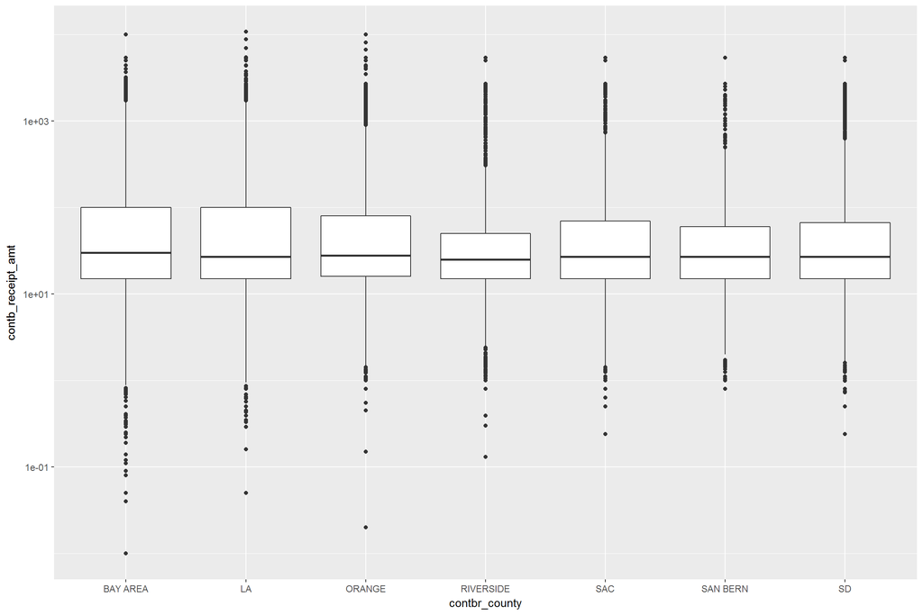

```
## CA$contbr_county: BAY AREA
##     Min.  1st Qu.   Median     Mean  3rd Qu.     Max.
## -10500.0     15.0     30.0    131.7    100.0  10000.0
## --------------------------------------------------------
## CA$contbr_county: LA
##    Min. 1st Qu.  Median    Mean 3rd Qu.    Max.
##   -8900      15      27     145     100   10800
## --------------------------------------------------------
## CA$contbr_county: NULL
##      Min.   1st Qu.    Median      Mean   3rd Qu.      Max.
## -10000.00     15.00     27.00     96.04     75.00  10800.00
## --------------------------------------------------------
## CA$contbr_county: ORANGE
##     Min.  1st Qu.   Median     Mean  3rd Qu.     Max.
## -8300.00    15.00    28.00   113.69    90.42 10800.00
## --------------------------------------------------------
## CA$contbr_county: RIVERSIDE
##     Min.  1st Qu.   Median     Mean  3rd Qu.     Max.
## -3700.00    15.00    25.00    70.82    50.00  5400.00
## --------------------------------------------------------
## CA$contbr_county: SAC
##     Min.  1st Qu.   Median     Mean  3rd Qu.     Max.
## -5400.00    14.00    26.40    88.53    70.00  5400.00
## --------------------------------------------------------
## CA$contbr_county: SAN BERN
##     Min.  1st Qu.   Median     Mean  3rd Qu.     Max.
## -5825.00    15.00    27.00    73.50    60.44  5400.00
## --------------------------------------------------------
## CA$contbr_county: SD
##     Min.  1st Qu.   Median     Mean  3rd Qu.     Max.
## -5400.00    15.00    27.00    85.37    73.45  5400.00
```

This is a boxplot of contribution amount vs. county. The summary statistics for each county were very similar. Because the y values were very spread out, I applied a log scale to the y axis.

# Bivariate Analysis

# Multivariate Plots Section

```r
### Add column for cumulative sum of amount, group by cand name and date
### This gives me the total contribution SO FAR, for each candidate on each
### date
CA$total_contbr <- ave(CA$contb_receipt_amt, CA$cand_nm,
                       CA$contb_receipt_dt_date, FUN=cumsum)

### Add column for max of total contribution
### This gives me the MAX of total contribution for each candidate on each
### date
CA$max_total_contbr <- ave(CA$total_contbr, CA$cand_nm,
                           CA$contb_receipt_dt_date, FUN=max)

### Need to sum over industries and counties
### Add column for cumulative sum of amount, group by industry and date
### This gives me the total contribution SO FAR, for each industry on
### each date
CA$total_contbr_industry <- ave(CA$contb_receipt_amt, CA$contbr_industry,
                                CA$contb_receipt_dt_date, FUN=cumsum)

### Add column for max of total contribution
### This gives me the MAX of total contribution for each industry on each
### date
CA$max_total_contbr_industry <- ave(CA$total_contbr_industry,
                                    CA$contbr_industry,
                                    CA$contb_receipt_dt_date, FUN=max)

### Add column for cumulative sum of amount, group by county and date
### This gives me the total contribution SO FAR, for each county on each
### date
CA$total_contbr_county <- ave(CA$contb_receipt_amt, CA$contbr_county,
                              CA$contb_receipt_dt_date, FUN=cumsum)

### Add column for max of total contribution
### This gives me the MAX of total contribution for each county on each date
CA$max_total_contbr_county <- ave(CA$total_contbr_county, CA$contbr_county,
                                  CA$contb_receipt_dt_date, FUN=max)
```

I created 6 new columns. The column ‘total_contbr’ gives me the cumulative sum for each candidate on each date SO FAR. The column ‘max_total_contbr’ gives me the MAX of total contributions for each candidate on each date. The column ‘total_contbr_industry’ gives the cumulative sum for each industry category on each date so far. ‘max_total_contbr_industry’ gives the max of total contributions for each industry category on each date. I repeated this process to create ‘total_contbr_county’ and ‘max_total_contbr_county’.

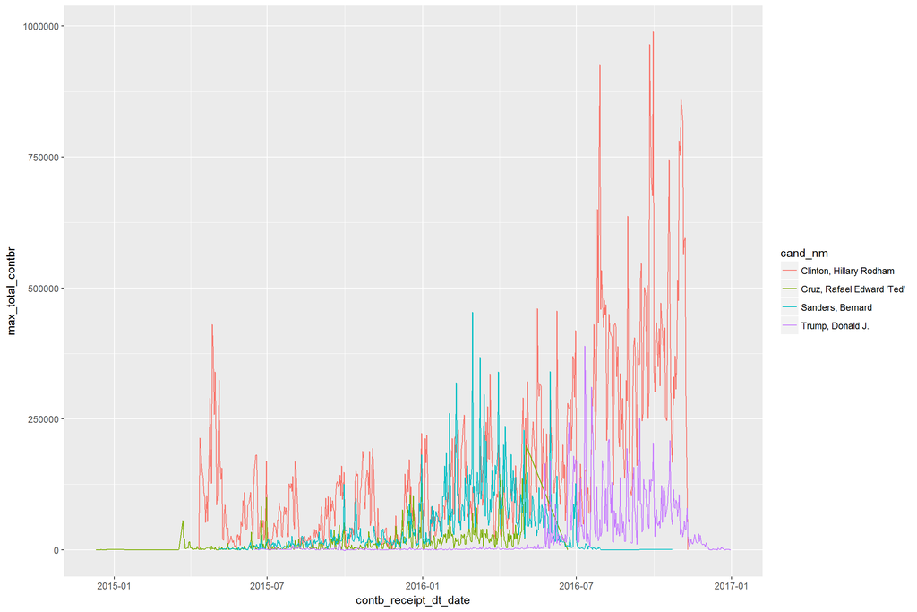

I made a line plot of max total contribution vs. date and grouped by candidate name.

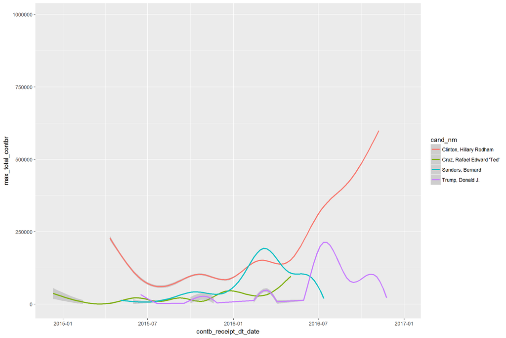

Smooth line plot of max total contribution vs. date and grouped by candidate name.

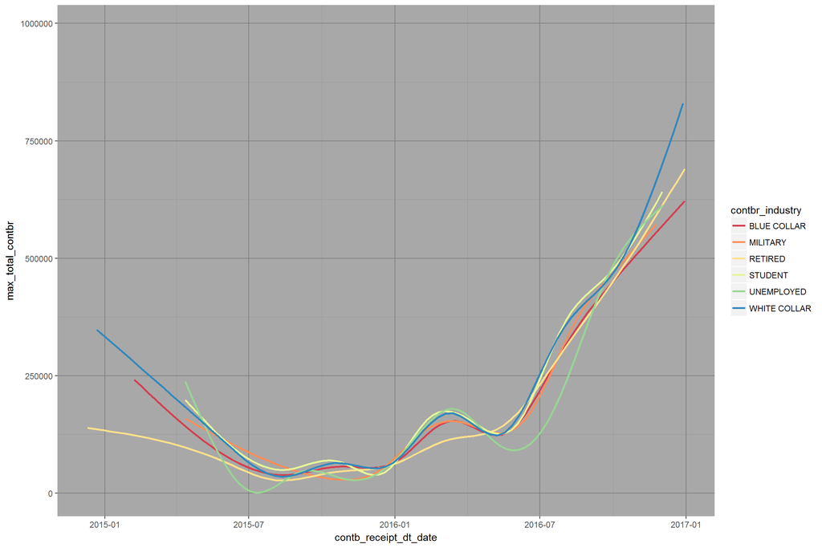

Grouped by industry category.

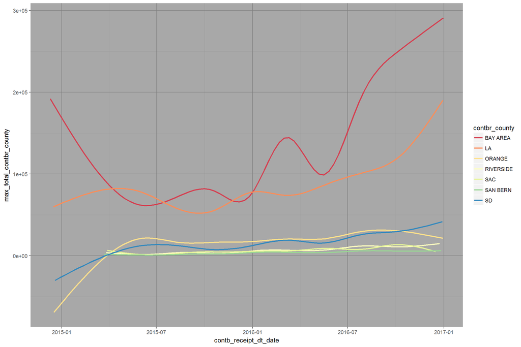

Grouped by County

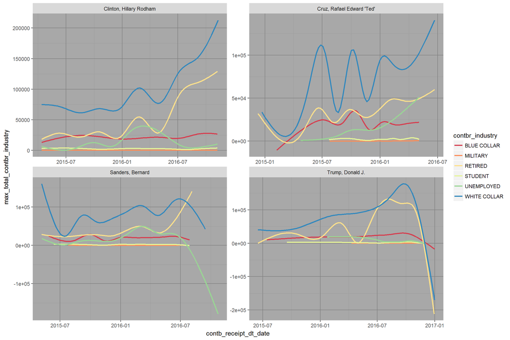

Smooth line plot of max contributions vs date, grouped by contbr_industry, facet wrapped by cand_nm

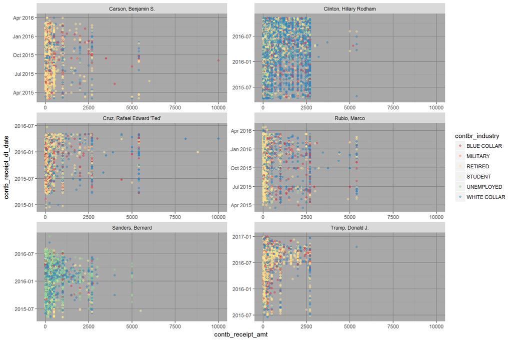

Scatter plot of contribution amount vs. date, colored by industry and facet wrapped by candidate name. Republican candidates had far more retired contributors. Bernie Sanders had a lot of unemployed contributors.

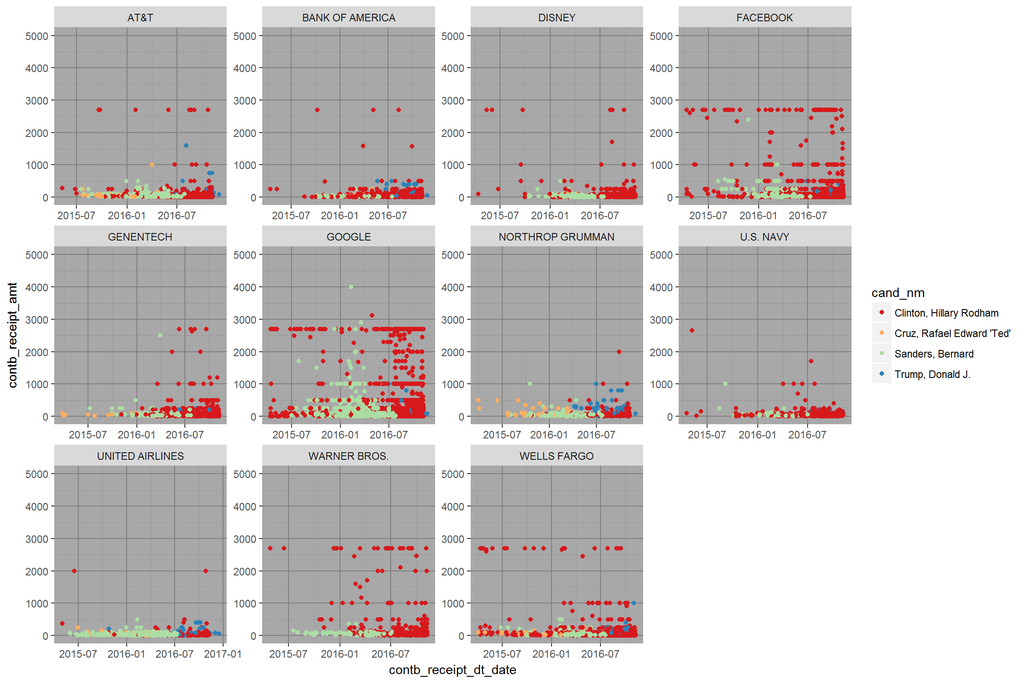

Scatter plot of contribution amount vs. date, colored by candidate name and facet wrapped by employer.

```r
# Add column that converts date to numeric value

CA$numeric_date <- as.numeric(CA$contb_receipt_dt_date)
```

I converted dates to numeric date values because I wanted to perform scaling operations on the date column in some of my plots.

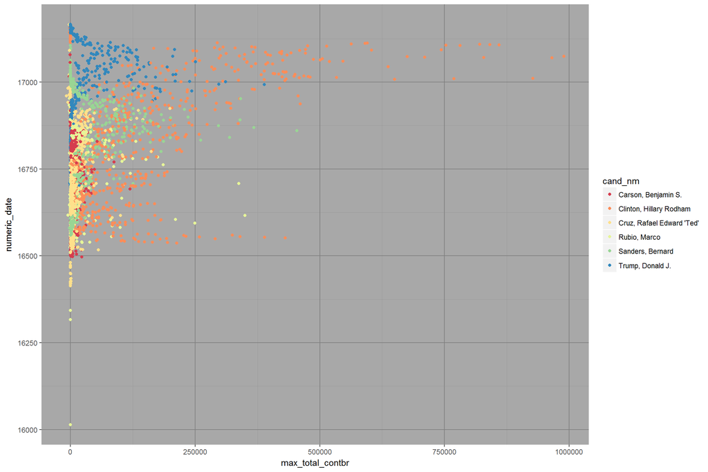

Earlier I looked contribution amount vs. date. This is numeric date vs. max total contribution amount, colored by candidate name. I chose to look at date as a function of contribution because one contribution amount has fewer date values than the number of contribution values that one date has. I was hoping to tease out a relationship between the date and contribution amount.

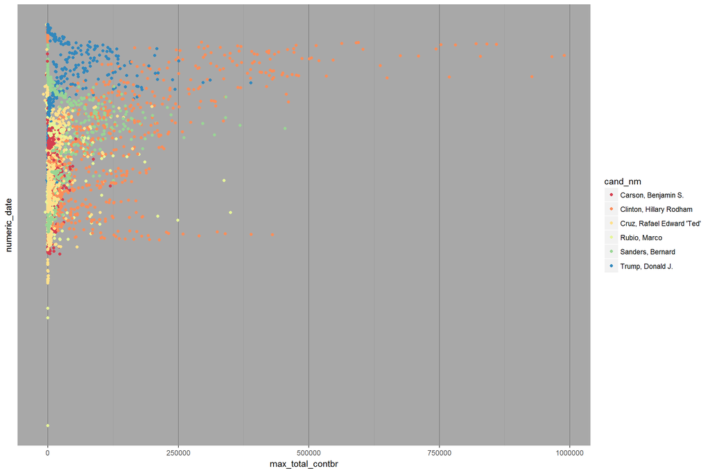

This is the log(numeric date) vs. max total contribution, colored by candidate name. Applying the log scale to the y axis helped show that higher contribution totals appeared closer to the election date. It was not a linear relationship but there was some correlation.

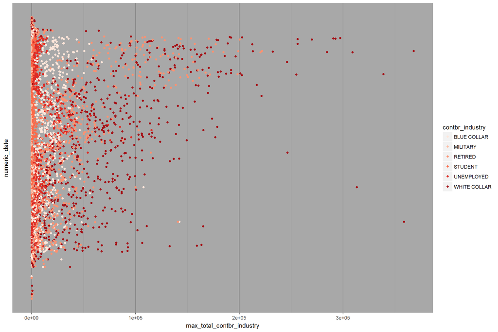

Log(numeric date) vs. max_total_contbr_industry, colored by contbr_industry.

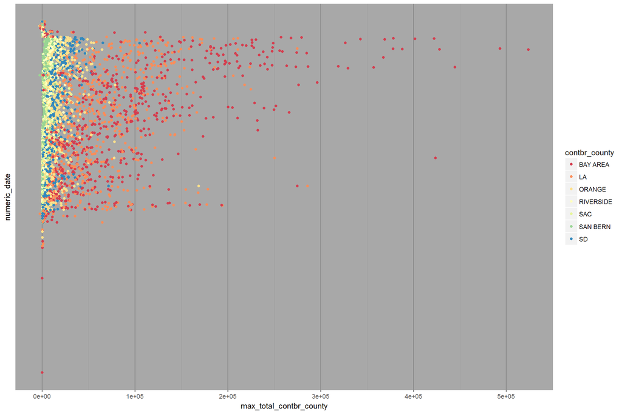

# Multivariate Analysis

### Talk about some of the relationships you observed in this part of the investigation. Were there features that strengthened each other in terms of looking at your feature(s) of interest?

The line plot of max total contributions vs. date shows only very small contributions to Trump’s campaign prior to June 2016. During this time, Ted Cruz had the majority of Republican contributions. After June 2016 the contributions per day to Trump’s campaign increased.

The scatterplot of amount vs. date, colored by contbr_industry and facet wrapped by cand_nm showed a large number of white collar contributors to Hillary Clinton’s campaign. The majority of contributors to Republican candidates were retired. Ben Carson, Ted Cruz, and Donald Trump had fewer white collar contributors. Bernie Sanders had a lot of unemployed contributors.

The scatterplot of amount vs. date, colored by cand_nm and facet wrapped by employer showed many of the selected companies to be dominated by Hillary Clinton supporters. Wells Fargo, United Airlines, Northrup Grumman, and AT&T held the most politically diverse employees.

### Were there any interesting or surprising interactions between features?

I didn’t expect contributors to Bernie Sanders and Donald Trump be from the same industry categories. There were many blue collar contributors to both candidates. The list of blue collar occupations I created mixed traditional blue collar jobs such as contruction or plumbing with modern jobs such as cashier or customer service. I was surprised at the high number of retired contributors.

# Final Plots and Summary

### Plot One

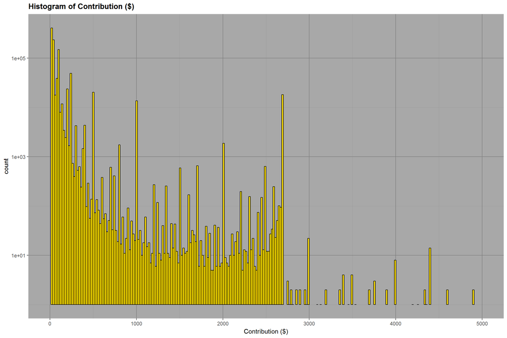

### Plot Two

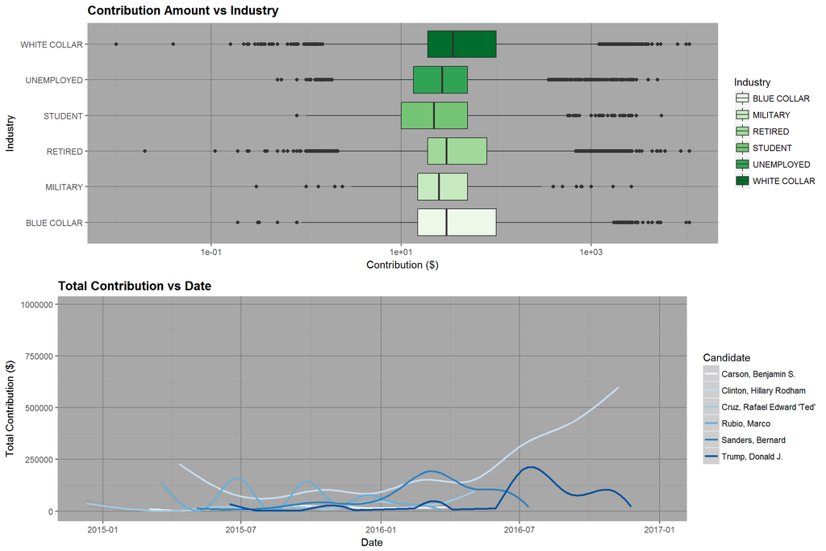

### Plot Three

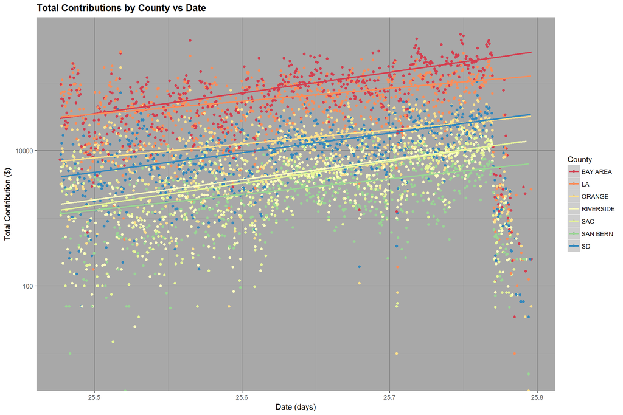

```
## [1] 0.3512009
```

### Description Three

I looked at the total contributions per date for each county. I converted dates to numeric date values so I could apply scaling operations to them. I applied a log scale to the y axis and a cube root scale on the x axis.  
I only included contributions to Hillary Clinton and Donald Trump. The correlation between the numeric date value and the total contribution per county was 0.351. ——

# Reflection

Most of the data was made up of large categorical variables. I had to find ways to organize these variables into fewer categories so I could include them in my plots. I used contributor occupations to create industry categories. I spent a lof of time creating lists of jobs to be included in my industry categories. There were a lot of jobs that were not clearly white collar or blue collar and my lists could be more thorough. I also used contributor cities to create contributor counties. The occupation and city data was difficult to use because I had to choose subsets of it to include in my analysis. There were too many occupations and cities to include in my lists for each category.

I created variables to sum contribution amounts over categorical variables such as candidate name, contributor industry category, contributor county. Upon converting the dates to numeric values I observed a correlation between numeric date and total contribution per candidate of 0.637. When I tested for correlation between numeric dates and total contribution per industry, the value was 0.432. The correlation between numeric dates and total contribution per county was 0.351. I had trouble deciding which of these three comparisons to show in my final plot. Although there were stronger correlations between candidate sums and industry sums, I wanted to show some data on which parts of California the money was coming from.

I was surprised to find a large number of military employees contributed to Bernie Sanders and Hillary Clinton. It was also surprising that Donald Trump received very small total contribution per date until the other Republican candidates were no longer an option. This analysis could be improved by programmatically reading the cities and occupations in the dataset and writing complete category lists for industry and county values. I would eventually like to predict the contribution amount or total contribution received in one day.